# step1_differentiate_subfamilies_VI_and_VII

Based on [this paper](http://www.plantphysiol.org/content/183/2/637/tab-figures-data#fig-data-additional-files) we want to see in what category our Azolla MYC-likes fall, perhaps reproduce some trees and check if the shared domains coïncide with what is described in the paper.

In this notebook, I'm attempting to reproduce some of the results of this paper and if I can reproduce the separation between the two subfamilies.

We're starting with family VI and VII MYBs. This is a screenshot of the supplementary figure for VI

Screenshot removed for copy-right reasons. Please find the supplementary information of [Jiang & Rao 2020](https://doi.org/10.1104/pp.19.01082) as linked above.

And for VII:

Screenshot removed for copy-right reasons. Please find the supplementary information of [Jiang & Rao 2020](https://doi.org/10.1104/pp.19.01082) as linked above.

Finally, I want to check if we find the domains like in this figure:

Screenshot removed for copy-right reasons. Please find the supplementary information of [Jiang & Rao 2020](https://doi.org/10.1104/pp.19.01082) as linked above.

# 0 Acquire data

And for Subfamily VII

- DN3051_co_g1_i1
- **HAOX-0009745**
- **Mapoly1089s0002**
- **MN199011**
- **Sacu_v1.1_s0002.g001222**
- **Sacu_v1.1_s0041.g012546**
- **Sacu_v1.1_s0272.g027033**
- **MA_96853g0010**
- **MA_10208000g0010**
- **MA_20462g0010**
- **AmTr_v1.0_scaffold00038.91**
- **AmTr_v1.0_scaffold00037.85**

Now the first step is to get those sequences from their various sources, store these in the data folder, check if I can align these and find the pattern shown in figure 2 of the paper (shown above) and finaly check if our Azolla filiculoides sequences fit in one or the other category.

DN3051_co_g1_i1: paper points to raw sequencing of the 1kP project. I don't have the patience for this so I'll leave this one out.

The VI sequences were mostly findable via ncbi. Sacu sequences were retrieved from fernbase.org. MA_ sequences are from the *Picea abies* genome and were retrieved from congenie.org. AmTr sequences were retrieved via jgi phytozome. After login, the original annotation files can be downloaded and searched for the genes of interest. It is a bit of a hassle to get them all.

Now to proceed, let's

1. Acquire data
2. linearise and combine
3. allign
4. identify domains
5. add Azolla sequences and repeat.
6. for the fun of it, make a phylogenetic tree

   I'm using code from my phylogenetics workflow here https://github.com/lauralwd/lauras_phylogeny_wf/blob/master/tree_building_workflow.ipynb

# 1 linearise and combine

```bash
tree
```

```
.
├── azolla_mycs.ipynb
├── conda-env.yaml
└── data
    ├── VII_sequences.fasta
    └── VI_sequences.fasta

1 directory, 4 files
```

```bash
for i in data/*fasta
do  inseq=$(echo $i | cut -d '/' -f 2 | cut -d '.' -f 1)
    cat data/$inseq.fasta \
     | awk '/^>/ {printf("%s%s\n",(N>0?"\n":""),$0);N++;next;} {printf("%s",$0);} END {printf("\n");}' \
     > data/"$inseq"_linear.fasta
done
```

```bash
#cat data/*_sequences_linear.fasta > data/combi_sequences_linear.fasta
cat data/VII_sequences_linear.fasta | sed 's/>/>VII_/' > data/combi_sequences_linear.fasta
cat data/VI_sequences_linear.fasta | sed 's/>/>VI_/' >> data/combi_sequences_linear.fasta
```

```bash
tree
```

```
.
├── azolla_mycs.ipynb
├── conda-env.yaml
└── data
    ├── combi_sequences_linear.fasta
    ├── VII_sequences.fasta
    ├── VII_sequences_linear.fasta
    ├── VI_sequences.fasta
    └── VI_sequences_linear.fasta

1 directory, 7 files
```

# 2 align

```bash
conda activate phylogenetics
```

```
(phylogenetics)
```

```bash
if    [ ! -d ./data/alignments_raw/ ]
then  mkdir  ./data/alignments_raw
fi
for   i in data/*sequences_linear.fasta
do    inseq=$(echo $i | cut -d '/' -f 2 | cut -d '.' -f 1)
      if    [ ! -f "./data/alignments_raw/$inseq"_aligned-mafft-linsi.fasta ]
      then  linsi --thread $(nproc) data/$inseq.fasta > ./data/alignments_raw/"$inseq"_aligned-mafft-linsi.fasta
      fi
done
```

[output not shown]

[output cut: 122 more lines]

[output not shown]

Aligning the VI dataset with mafft-e-ins-i based on observations on the linsi alignment in section three.

```bash
einsi --thread $(nproc) ./data/VI_sequences_linear.fasta > ./data/alignments_raw/VI_sequences_linear_aligned-mafft-einsi.fasta
```

[output not shown]

[output cut: 9 more lines]

[output not shown]

```bash
conda deactivate
```

```bash
tree data
```

```
data
├── alignments_raw
│   ├── combi_sequences_linear_aligned-mafft-linsi.fasta
│   ├── combi_sequences_linear_aligned-mafft-linsi.png
│   ├── VII_sequences_linear_aligned-mafft-linsi.fasta
│   ├── VII_sequences_linear_aligned-mafft-linsi.png
│   ├── VI_sequences_linear_aligned-mafft-einsi.fasta
│   ├── VI_sequences_linear_aligned-mafft-linsi.fasta
│   └── VI_sequences_linear_aligned-mafft-linsi.png
├── combi_sequences_linear.fasta
├── VII_sequences.fasta
├── VII_sequences_linear.fasta
├── VI_sequences.fasta
└── VI_sequences_linear.fasta

1 directory, 12 files
```

# 3 Identify domains

## reproducing Jiang & Rao

### linsi alignments

Now let's look at the linsi alignments. If I open them in jalview, I get something like this for VI.

[figure not shown]

VII

[figure not shown]

and both combined

[figure not shown]

There are clearly conserved domains, and especially in VI, there is a super long tail of extra sequence in one of the rows.

And I'm looking for these...

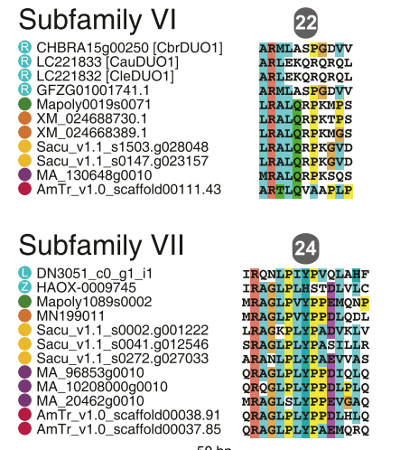

For subfamily VI this domain is not aligned as in the Jiang & Rao paper:

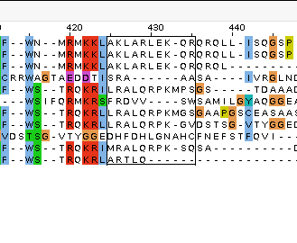

For the VII subfamily hower, the linsi method was fine.

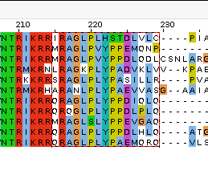

Intermediate conclusion: The VII subfamily nicely aligns, but the VI is too gappy and the linsi method doesn't do so well in this case. Let's try different MAFFT methods for this alignment.

### einsi alignment

[figure not shown]

And the section of interest looks like so:

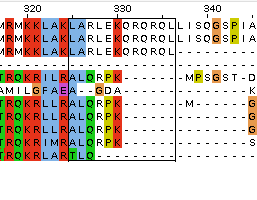

Clearly, this does not succeed in reproducing the L&R paper's results.

### combi alignment

Now let's have a look at the combi alignment, to see if we can actually overlap these regions and use them to differentiate between the two subfamilies.

[figure not shown]

It's not exactly the comparison from the J&R paper, but I can differentiate between the two based on this domain in the linsi alignment. I proceed in a medium-convinced state

# 5. phylogeny

I'm skipping step four for now, and quickly making the phylogeny for this set of sequences to see if the differentation I see on this one domain persists.

I'm planning on trimal column trimming and IQtree 100 bootstraps.

## 5.1 trimming

```bash
conda activate phylogenetics
if    [ ! -d data/alignments_trimmed ]
then  mkdir  data/alignments_trimmed
fi

# define appendix only once here:
trimappendix='trim-gt6'

inseq=combi_sequences_linear
for a in "data/alignments_raw/$inseq"_aligned*.fasta
do  appendix=$(echo $a | cut -d '/' -f 3- | sed "s/$inseq\_//" | sed "s/.fasta//")
    if    [ ! -f data/alignments_trimmed/"$inseq"_"$appendix"_"$trimappendix".fasta ]
    then  echo "trimming alignment $a"
          sed -i 's/ /_/g' $a
          trimal -in $a   \
                 -out data/alignments_trimmed/"$inseq"_"$appendix"_"$trimappendix".fasta \
                 -gt .6 \
                 -htmlout data/alignments_trimmed/"$inseq"_"$appendix"_"$trimappendix".html
    fi
done
conda deactivate
```

```
(phylogenetics) (phylogenetics) (phylogenetics) (phylogenetics) (phylogenetics) (phylogenetics) (phylogenetics) trimming alignment data/alignments_raw/combi_sequences_linear_aligned-mafft-linsi.fasta
(phylogenetics)
```

```bash
tree data/alignments_trimmed
```

[output not shown]

For gap threshold 80%

[figure not shown]

For gap threshold 60%

[figure not shown]

For gap threshold 40%

[figure not shown]

and for gap threshold 20%

[figure not shown]

All allignments contain the differentiating domain as published in J&R. 40% is too gappy for my taste, so I will take the 60% all for tree inference. However, supervisor will like 40% better so I'll run that too.

## 5.2 tree inference

```bash
inseq=combi_sequences_linear
echo $inseq
```

```
combi_sequences_linear
```

```bash
ls data/alignments_trimmed/"$inseq"_aligned*gt[46].fasta
```

```
data/alignments_trimmed/combi_sequences_linear_aligned-mafft-linsi_trim-gt4.fasta
data/alignments_trimmed/combi_sequences_linear_aligned-mafft-linsi_trim-gt6.fasta
```

```bash
conda activate phylogenetics
for a in data/alignments_trimmed/"$inseq"_aligned*gt[46].fasta
do  iqpendix='iqtree-b100'
    #iqpendix='iqtree-bb2000-alrt2000'

    echo "making a tree of file $a"
    echo "The first lines of alignment $a look like this"
    head $a

    file_appendix=$(echo $a | cut -d '/' -f 3- | sed "s/$inseq\_//" | sed "s/.fasta//")

    if   [ ! -d    analyses/"$inseq"_trees/"$file_appendix" ]
    then echo "Making a directory $file_appendix to store trees (name based on alignment filename)"
         mkdir -p  analyses/"$inseq"_trees/"$file_appendix"
    fi

    iqprefix=analyses/"$inseq"_trees/"$file_appendix"/"$inseq"_"$file_appendix"_"$iqpendix"
    if   [ ! -f "$iqprefix".tree ]
    then nice iqtree -s $a \
                     -m MFP \
                     -b 100 \
                     -nt AUTO \
                     -ntmax $(nproc)  \
                     -pre  "$iqprefix" \
                     2>   "$iqprefix".stderr \
                      >    "$iqprefix".stdout
    cat "$iqprefix".log | mail -s "IQtree_run $a" laura
    fi
done
conda deactivate
```

```
(phylogenetics) making a tree of file data/alignments_trimmed/combi_sequences_linear_aligned-mafft-linsi_trim-gt4.fasta
The first lines of alignment data/alignments_trimmed/combi_sequences_linear_aligned-mafft-linsi_trim-gt4.fasta look like this
>HAOX-0009745
--------------------------------GLKKGPWTAEEDVILSEYVMKHGEGNWN
LIQKNTGLPRCGKSCRLRWANHLRPNLKKG-AFSREEEALVIKLHAEIGNKWARMALQLP
GRTDNEIKNFWNTRIKRRIRAG-LPLHSTDLVLCPIAT------TTPFREKLTEYMEESR
DTKPIDRDSDDCDHTN--------------------------------------------
------------------------------------------------------------
------------------------------------------------------------
------------------------------------------------------------
------------------------------------------------------------
-------------------------------------------------------
making a tree of file data/alignments_trimmed/combi_sequences_linear_aligned-mafft-linsi_trim-gt6.fasta
The first lines of alignment data/alignments_trimmed/combi_sequences_linear_aligned-mafft-linsi_trim-gt6.fasta look like this
>HAOX-0009745
----------------GLKKGPWTAEEDVILSEYVMKHGEGNWNLIQKNTGLPRCGKSCR
LRWANHLRPNLKKGAFSREEEALVIKLHAEIGNKWARMALQLPGRTDNEIKNFWNTRIKR
RIRAGLPLHSTDLVLCPTTPFREKLTEYMEESRDTKPIDRDSD-----------------
------------------------------------------------------------
-----------------------------
>Mp3g05910.1
MEL--GSAPDFSEDVGALKKGPWTSAEDAILVAYVTKHGEGNWNSVQKHSGLYRCGKSCR
LRWANHLRPNLKKGAFTPEEERMIIELHAKLGNKWARMAAQLPGRTDNEIKNYWNTRIKR
RMRAGLPVYPPEMQNPA------ANSQYLFEHGEMSMSSGGESMSDLPLSSVVTQTDTQC
(phylogenetics)
```

## 5.3 tree results

Uploading the trees to iToL, see links.

One of the XM_ sequences doesn't belong here, I extracted the wrong seqeunce so I'm removing that. Based on branch length I'm also inclined to remove the GFZ sequence; I don't trust it. However, I will inspect the alignment and annotation before actually removing it.

### 40% gt

Red is VI

Green is VII

gt 40% propper bootstraps:

[figure not shown]

[propper bootstrap](https://itol.embl.de/tree/1312115964466181596025313#) and [ultrafast](https://itol.embl.de/tree/1312115964280461596023024)

### 60% gt

gt 60% propper bootstraps:

[figure not shown]

[propper bootstrap](https://itol.embl.de/tree/131211596438011596027537#) and [ultrafast](https://itol.embl.de/tree/1312115964280541596023027)

Overall this isn't winning a beauty contest, but the node separating VI from VII has decent support 92% for normall bootstraps and practically 100 for UFbootstrap+ALRT.

Oddly placed sequences can be attributed to my mistakes, so overal I feel confident enough to add Azolla sequences to this and see if I can confidently place them in one or the other category. Both on the alignment and the tree level; preferably a combination of both.